# Experimento 01 Auditor Crawler

## Problema

A ausência de estratégias de recuperação da informação eficientes e de caráter eficaz, com aplicação robusta no contexto da identificação e avaliação automática de critérios fiscais em portais de transparência municipais.

## Contexto

Com base no problema apresentado, este trabalho propôs a utilização e validação de crawlers para avaliar automaticamente portais municipais de transparência. Assim, durante a pesquisa foi implementado um crawler focado (crawlers aplicados a um contexto único) para avaliar os portais de transparência dos municipios do estado da Paraíba, utilizando como diretrizes de avaliação e validação da solução o Índice de transparência Municipal criado pelo Tribunal de Contas da Paraíba (TCE-PB). Por meio do ìndice foram elicitados todos os itens utilizados na avaliação de cada portal.

Neste contexto, com o objetivo de construir uma solução eficaz, eficiente e robusta foram experiementadas diferentes formas de buscar por novas páginas, partindo da premissa que o modo de percorrer e buscar novas páginas possui impacto direto na perfomace e manuteção destas caraterísticas. Desta forma, foram avaliados 3 diferentes algoritmos, sendo dois algoritmos tradicionais neste tipo de aplicação (BFS e DFS) e outro encontrado através da litertatura o E-greedy.

## Experimento 1

Neste experimento foi avaliado o desempenho do crawler focado na avaliação da transparênica comparando a uso dos Algoritmos Bfs, Dfs em relação ao Epsilon-greedy durante a busca e identificação dos critérios ficais nos sites de transparência. Este experimento tentar responder as seguintes perguntas:

1. Como se comporta o crawler em relação ao Recall e Precisão considerando os diferentes algoritmos durante as avaliações de transparência (Eficácia)?
2. Como se comporta o crawler em relação a número de nós acessados considerando os diferentes algoritmos durante as avaliações (Eficiência)?
3. Como é a estabilidade do crawler considerando cada um dos algoritmos e as combinação de portal de transparência?

Para responder essas perguntas foram utilizadas as seguintes variáveis:

- Recall de cada avaliação;
- Precisão de cada avaliação;
- Número máximo de nós acessados;
- Mediana do número de nós acessados;
- Duração máxima em minutos da avaliação;
- Mediana da duração da avaliação em minutos;
- Combinação de portais de transparência;

Obs: Um nó pode ser representado por um link ou um componente clicável em páginas da web.

## Avaliações válidas

As avaliações válidas são execuções do Crawler que tiveram entre os critérios fiscais avaliados 61 itens pesquisados. Deste modo, para evitar ruídos que possam impactar nos resultados, todas as avaliações que não contínham este padrão de validade foram descartadas. Além disso, as avaliações do município de *Curral de Cima* não foram consideradas por seu portal de transparência está atualmente fora do ar, restando 29 municípios na amostra.

## Um exemplo dos dados utilizados

| id | date | municipio | criterio | item | aproach | tp | contNodeNumberAccess | durationMin |
| --- | --- | --- | --- | --- | --- | --- | --- | --- |
| 5dc5da1b306dcf1806a6cfec | 2019-11-09 00:10:30 | Santa Rita | Receita Extra Orçamentária | valor | Bfs | TRUE | 5 | 11 |
| 5dc5da1b306dcf1806a6cfed | 2019-11-09 00:10:30 | Santa Rita | Receita Extra Orçamentária | codigo | Bfs | TRUE | 5 | 11 |
| 5dc5da1b306dcf1806a6cfee | 2019-11-09 00:10:30 | Santa Rita | Receita Extra Orçamentária | nomenclatura | Bfs | TRUE | 5 | 11 |
| 5dc5da1c38fb0516fbbe8e34 | 2019-11-09 00:10:23 | Ouro Velho | Quadro Pessoal | nome | Bfs | FALSE | 4 | 6 |
| 5dc5da1c38fb0516fbbe8e35 | 2019-11-09 00:10:23 | Ouro Velho | Quadro Pessoal | cpf | Bfs | FALSE | 4 | 6 |
| 5dc5da1c38fb0516fbbe8e36 | 2019-11-09 00:10:23 | Ouro Velho | Quadro Pessoal | cargo | Bfs | TRUE | 4 | 6 |

## Quantificando métricas

Calculando Recall, Precision, F1 Score e métricas relacionadas ao desempenho do Auditor Crawler.

## Número de Avaliações por Algoritmo

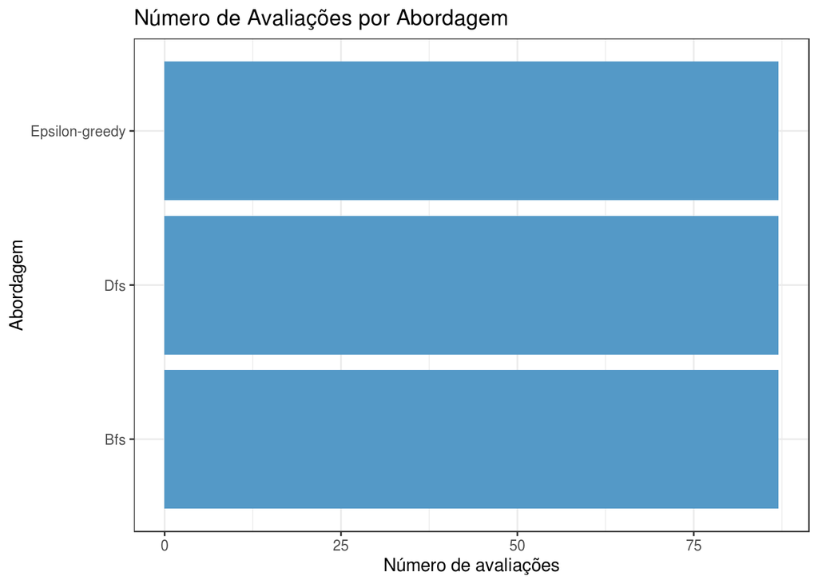

Foram coletadas entre os algoritmos 3 avaliações por portal de transparência. No total foram realizadas proporcionalmente 261 avalições dividas entre os 29 portais da amostra e os algoritmos de busca avaliados.

## Como se comporta o crawler em relação ao Recall e a Precisão considerando os diferentes algoritmos durante as avaliações de transparência (Eficácia)?

Para avaliar a eficácia do crawler com uso dos diferentes algoritmos propostos foram utilizadas as métricas Recall e Precisão. A escolha destas métricas foi motivada pela necessidade do equilíbrio entre os valores obtidos para Recall e Precision, em outras palavras, da necessidade de uma avaliação de transparência que consiga identificar a maior quantidade de itens possível (Recall) e que mantenha uma alta confiabilidade nos itens identificados (Precision).

### Recall das avaliações por algoritmo

A Figura x apresenta a distribuição e a mediana dos valores de Recall das avaliações entre os diferentes algoritmos de buscas experimentados.

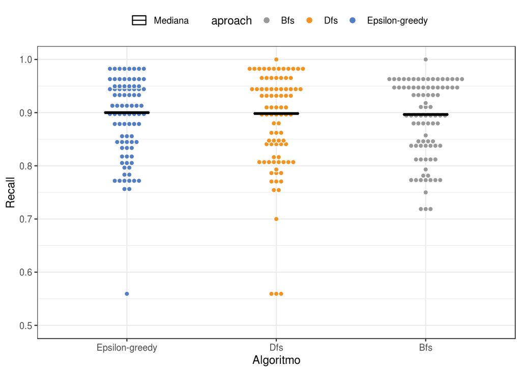

Na Figura x, é possível observar uma semelhança entre as distribuições do Recall nas avaliações para cada um dos algoritmos, estando a maior parte das avaliações entre as faixas de valores de 0.7 até 1. Apesar disto, existem alguns outiles situados abaixo destas faixas de valores e encontrados nos resultados obtidos com os algoritmos Epsilon-greedy e Dfs. Estes fazem parte de avaliações pertecentes ao portal de transparência do município de Remígio, ao qual o crawler utilizando Epsilon-greedy ou DFs não consegue lidar com as sessões temporárias dentro de iframes de forma efetiva, devido o acesso não sequencial aos nós e a má prática no uso de iframes embutidos nas páginas deste site. Além disso, comparando as medianas entre os algoritmos é imperceptível a diferença entre os métodos de busca, variando entre 0.90 (Epsilon-greedy) e 0.89 (Dfs e Bfs).

#### Intervalos de Confiança da mediana do Recall

```
## Observations: 1
## Variables: 5
## $ statistic <dbl> 0.8965517
## $ bias      <dbl> 0.003909517
## $ std.error <dbl> 0.01283753
## $ conf.low  <dbl> 0.877193
## $ conf.high <dbl> 0.9180328
## # A tibble: 1 x 5
##   statistic    bias std.error conf.low conf.high
##       <dbl>   <dbl>     <dbl>    <dbl>     <dbl>
## 1     0.897 0.00391    0.0128    0.877     0.918
## Observations: 1
## Variables: 5
## $ statistic <dbl> 0.8983051
## $ bias      <dbl> 0.004736428
## $ std.error <dbl> 0.01444212
## $ conf.low  <dbl> 0.8474576
## $ conf.high <dbl> 0.9285714
## # A tibble: 1 x 5
##   statistic    bias std.error conf.low conf.high
##       <dbl>   <dbl>     <dbl>    <dbl>     <dbl>
## 1     0.898 0.00474    0.0144    0.847     0.929
## Observations: 1
## Variables: 5
## $ statistic <dbl> 0.9
## $ bias      <dbl> 0.00408753
## $ std.error <dbl> 0.01082965
## $ conf.low  <dbl> 0.8813559
## $ conf.high <dbl> 0.9285714
## # A tibble: 1 x 5
##   statistic    bias std.error conf.low conf.high
##       <dbl>   <dbl>     <dbl>    <dbl>     <dbl>
## 1       0.9 0.00409    0.0108    0.881     0.929
```

#### IC Diferença Recall do Epsilon-greedy e Dfs

Como visto na Figura x, os algoritmos que obtiveram maiores valores Recall foram Epsilon-greedy e Dfs. Assim, foram criados intervalos de confiança para a diferença entre eles. Estes intervalos de confiança são mostrados na Figura u.

```
## Observations: 1
## Variables: 5
## $ statistic <dbl> 0.001694915
## $ bias      <dbl> -0.0006882293
## $ std.error <dbl> 0.01829673
## $ conf.low  <dbl> -0.03292715
## $ conf.high <dbl> 0.04864532
```

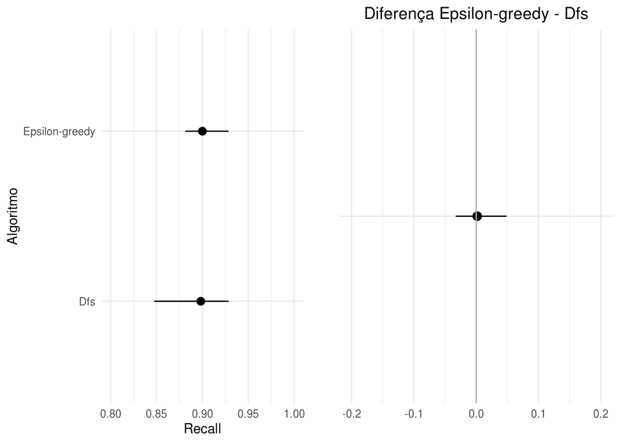

A partir dos intervalos de confiança da mediana e da diferença entre os algoritmos Epsilon-greedy e Dfs mostrados na Figura u, é possível observar que os intervalos estão localizados entre 0.84 a 0.92 na Dfs e 0.88 a 0.92 no Epsilon-greedy. Além disso, baseado na diferença *Epsilon-greedy-Dfs* é possível verificar com 95% de confiança o sentido e a grandeza da diferença entre os algoritmos Epsilon greedy e Dfs em relação aos valores da mediana do Recall. As barras de erros do itervalo de confiança variam de -0.032 até 0.048, podendo assumir tanto valores positivos quanto negativos. Neste cenário, não é possível comprovar a existência de um desempenho superior no uso Epsilon-greedy na obtenção do Recall em comparação com a Dfs, devido ao pequeno intervalo e por ele conter o valor 0.

#### IC Diferença Recall do Epsilon-greedy e Bfs

De acordo com a Figura x, fica evidente a discreta variação (0.01) entre os resultados obtidos para Recall entre os agoritmos de busca. Sob esta pespectiva e considerando que o algoritmo Bfs é o algoritmo de busca base do crawler focado proposto neste trabalho, foram também comparados os algoritmos Epsilon-greedy e Bfs. Esta comparação foi realizada com crição a de intervalos de confiança para mediana dos dois algoritmos e a diferença entre as medianas deles.

```
## Observations: 1
## Variables: 5
## $ statistic <dbl> 0.003448276
## $ bias      <dbl> -0.0002411828
## $ std.error <dbl> 0.01657806
## $ conf.low  <dbl> -0.03114302
## $ conf.high <dbl> 0.03594389
```

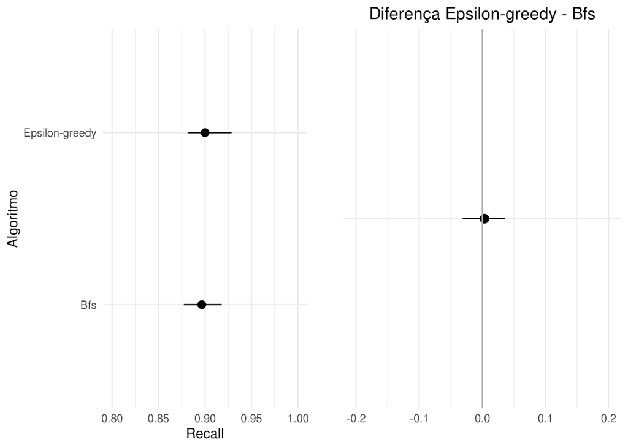

De acordo com os resultados mostrados para os intervalos de confiança apresentados na Figura u e p, é possível extender os resultados para a comparação entre os algoritmos Dfs e Bfs, devido a semelhança entre os resultados obtidos. Além disso, de acordo com os intervalos não foi possível confirmar a existência de uma superioridade nos valores para a mediana do Recall durante as avaliações no uso destes algoritmos.

### Precisão das avaliações por algoritmo

A Figura y exibe a distribuição e a mediana dos valores da Precisão das avaliações entre os diferentes algoritmos de buscas experimentados.

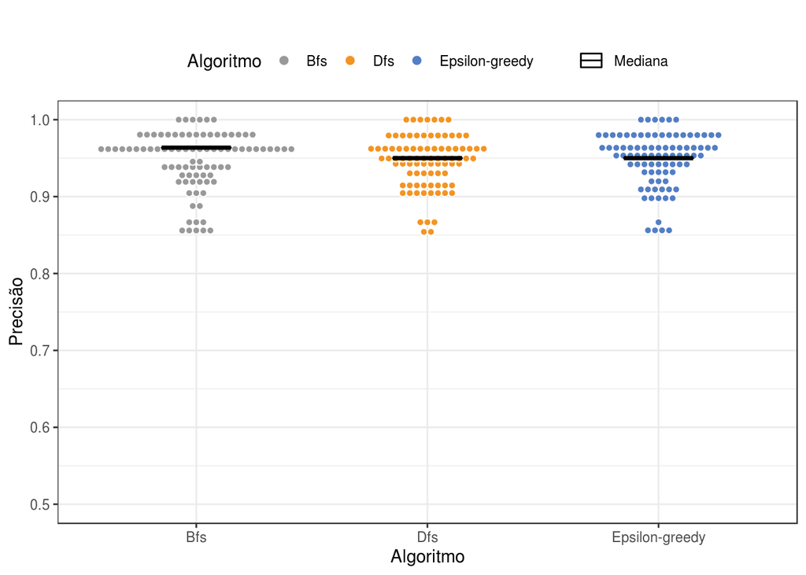

Com base na Figura y, constata-se que as faixas de valores da Precisão das avaliações entre os algoritmos são similares, variando entre 0.85 até 1. Ademais, os valores das medianas apresentaram pequenas mudanças nos mesmos, situados entre 0.95 (Epsilon-greedy e Dfs) e 0.96 (Bfs). Porém, esta variação, assim como nas medianas do Recall, é de apenas 0.01. Assim, para avaliar as diferenças nestes valores foram criados itervalos de confiança para a mediana dos algoritmos de busca.

#### Intervalos de Confiança da mediana de Precisão

```
## Observations: 1
## Variables: 5
## $ statistic <dbl> 0.9636364
## $ bias      <dbl> -0.002228383
## $ std.error <dbl> 0.005086828
## $ conf.low  <dbl> 0.9423077
## $ conf.high <dbl> 0.9655172
## # A tibble: 1 x 5
##   statistic     bias std.error conf.low conf.high
##       <dbl>    <dbl>     <dbl>    <dbl>     <dbl>
## 1     0.964 -0.00223   0.00509    0.942     0.966
## Observations: 1
## Variables: 5
## $ statistic <dbl> 0.95
## $ bias      <dbl> -0.0001932527
## $ std.error <dbl> 0.002647808
## $ conf.low  <dbl> 0.9428571
## $ conf.high <dbl> 0.95
## # A tibble: 1 x 5
##   statistic      bias std.error conf.low conf.high
##       <dbl>     <dbl>     <dbl>    <dbl>     <dbl>
## 1      0.95 -0.000193   0.00265    0.943      0.95
```

```
## Observations: 1
## Variables: 5
## $ statistic <dbl> 0.95
## $ bias      <dbl> 0.00446904
## $ std.error <dbl> 0.005443974
## $ conf.low  <dbl> 0.9375
## $ conf.high <dbl> 0.95
## # A tibble: 1 x 5
##   statistic    bias std.error conf.low conf.high
##       <dbl>   <dbl>     <dbl>    <dbl>     <dbl>
## 1      0.95 0.00447   0.00544    0.938      0.95
```

#### IC Diferença Precisão do Bfs e Dfs

```
## Observations: 1
## Variables: 5
## $ statistic <dbl> 0.01363636
## $ bias      <dbl> -0.001808174
## $ std.error <dbl> 0.005651032
## $ conf.low  <dbl> -0.00788046
## $ conf.high <dbl> 0.01886792
```

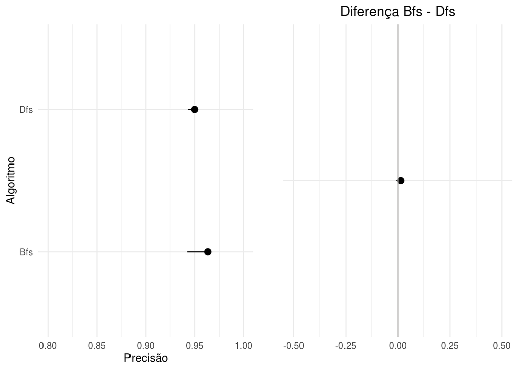

#### IC Diferença Precisão do Bfs e Epsilon-greedy

```
## Observations: 1
## Variables: 5
## $ statistic <dbl> 0.01363636
## $ bias      <dbl> -0.006705559
## $ std.error <dbl> 0.007315384
## $ conf.low  <dbl> 0.001450677
## $ conf.high <dbl> 0.02239724
```

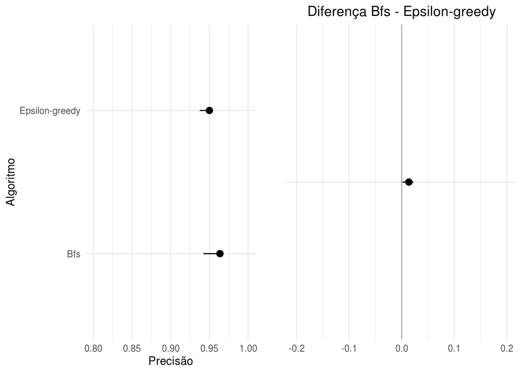

## Como se comporta o crawler em relação a número de nós acessados considerando os diferentes algoritmos durante as avaliações (Eficiência)?

Para avaliar a perfomance do Crawler focado com o uso dos diferentes algoritmos, foi empregado o uso a mediana do número de nós acessados entre os critérios fiscais pesquisados em cada avaliação. Esta métrica foi escolhida em virtude de sua maior estabilidade em relação a possíveis instabilidades ocorridas durante as avaliações, pois independentemente da duração da avaliação, o número de nós acessados deve permancer similar considerando um mesmo portal. Neste cenário, a Figura y mostra a distribuição da mediana do número de nós acessados entre os critérios fiscais nas avaliações entre os três algoritmos testados.

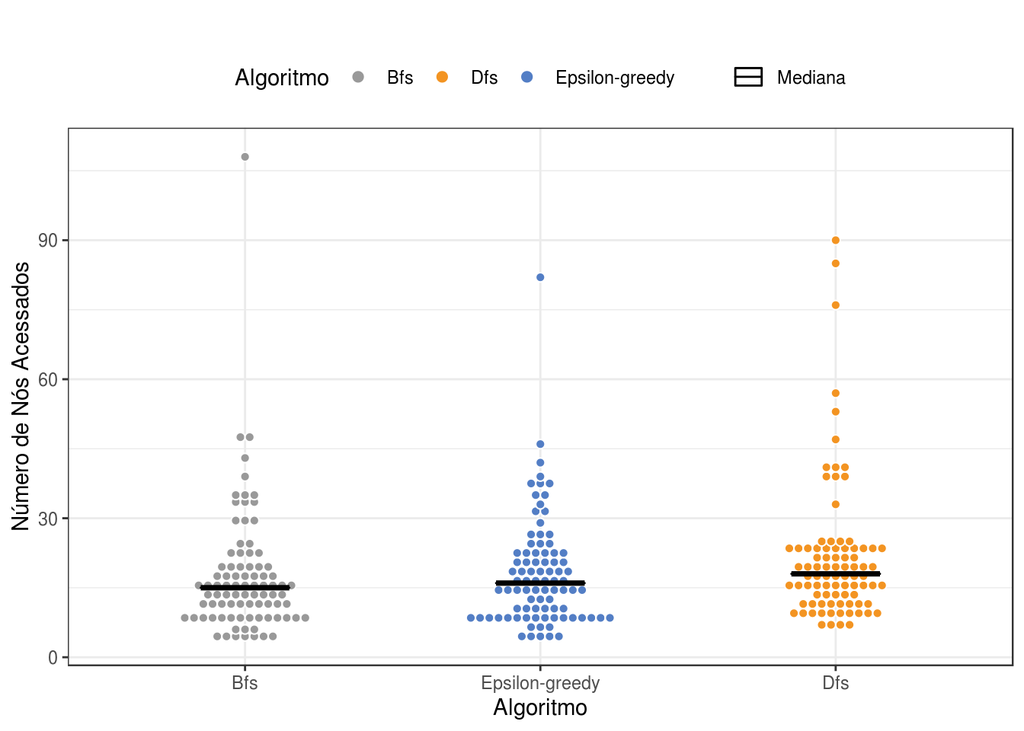

Para validar essa análise, aplicamos intervalos de confiança com a utilização de bootstraps (4000).

### Intervalos de confiança para Número de Nós acessados

Com base no objetivo de avaliar o algoritmo Epsilon-greedy em relação a algoritmos clássicos no que se refere a busca por novas páginas no processo de crawling, foram criados intervalos de confiança para a mediana de nós acessados entre os critérios fiscais para os algoritmos Bfs que obteve melhor resultado e o Epsilon-greedy.

```
## Observations: 1
## Variables: 5
## $ statistic <dbl> 15
## $ bias      <dbl> -0.4155
## $ std.error <dbl> 0.8732413
## $ conf.low  <dbl> 12
## $ conf.high <dbl> 16
## # A tibble: 1 x 5
##   statistic   bias std.error conf.low conf.high
##       <dbl>  <dbl>     <dbl>    <dbl>     <dbl>
## 1        15 -0.415     0.873       12        16
## Observations: 1
## Variables: 5
## $ statistic <dbl> 18
## $ bias      <dbl> 0.12575
## $ std.error <dbl> 1.129936
## $ conf.low  <dbl> 15
## $ conf.high <dbl> 19
## # A tibble: 1 x 5
##   statistic  bias std.error conf.low conf.high
##       <dbl> <dbl>     <dbl>    <dbl>     <dbl>
## 1        18 0.126      1.13       15        19
## Observations: 1
## Variables: 5
## $ statistic <dbl> 16
## $ bias      <dbl> -0.17425
## $ std.error <dbl> 1.179718
## $ conf.low  <dbl> 14
## $ conf.high <dbl> 19
## # A tibble: 1 x 5
##   statistic   bias std.error conf.low conf.high
##       <dbl>  <dbl>     <dbl>    <dbl>     <dbl>
## 1        16 -0.174      1.18       14        19
```

#### IC Diferença Mediana do Número de nós do Bfs e Epsilon-greedy

```
## Observations: 1
## Variables: 5
## $ statistic <dbl> -1
## $ bias      <dbl> -0.25775
## $ std.error <dbl> 1.461326
## $ conf.low  <dbl> -5.5
## $ conf.high <dbl> 0
```

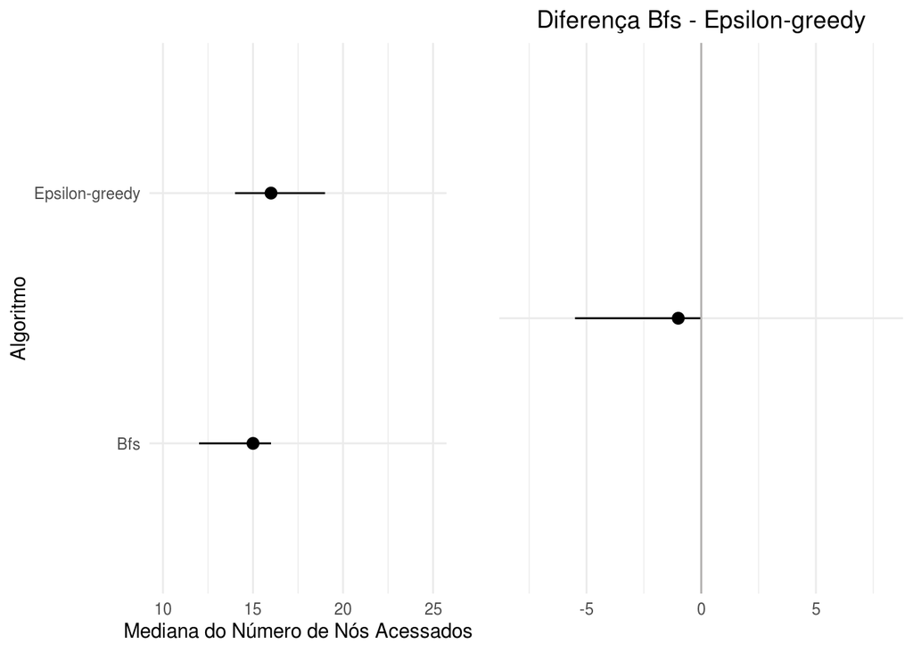

De acordo com a Figura l é observado que os intervalos das medianas do número de nós acessados estão entre o limites da mediana de nós acessados de 14 a 19 no Epsilon-greedy e de 12 a 16 na Bfs. Ademais, por meio do intervalo da diferença entre *Bfs - Epsilon-greedy* é possível constatar que pode existir uma redução de até 5 nós na mediana do número de nós acessados nas avaliações com uso da Bfs ou mesmo que está diferença seja moderada ou inexistente.

#### IC Diferença Mediana do Número de nós do dfs e Epsilon-greedy

```
## Observations: 1
## Variables: 5
## $ statistic <dbl> -2
## $ bias      <dbl> -0.279625
## $ std.error <dbl> 1.645387
## $ conf.low  <dbl> -5
## $ conf.high <dbl> 1.5
```

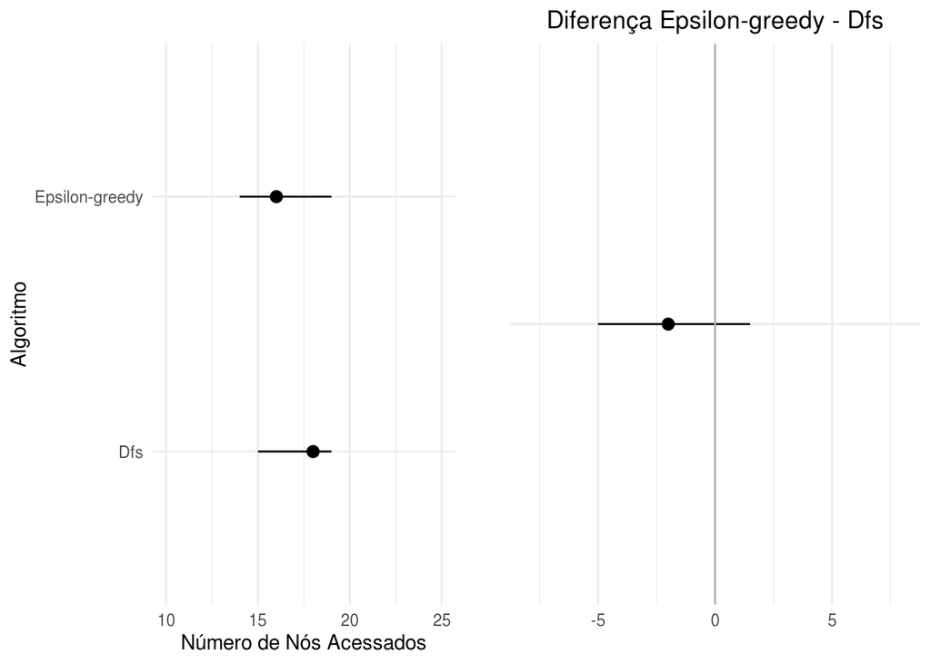

Conforme é mostrado na Figura h, é notado a que os intervalos de confiança das medianas do número de nós acessados encontram-se entre 15 a 19 na Dfs eentre 14 a 19 no Epilson-greedy. No mais, por meio do intervalo de confiança da diferença entre *Epsilon-gredy - Dfs* é possível identificar que pode existir uma diferença positiva de até 5 nós a menos nos resultados na mediana do número de nós acessados no uso do algoritmo Epsilon-greedy em comparação a Dfs. Porém pode acontecer apenas uma moderada ou inesxistente diferença entre eles ou mesmo esta diferença ser negativa em relação a escolha do Epsilon-greedy.

```
## Observations: 1
## Variables: 5
## $ statistic <dbl> -3
## $ bias      <dbl> -0.510125
## $ std.error <dbl> 1.413403
## $ conf.low  <dbl> -6
## $ conf.high <dbl> -0.5
```

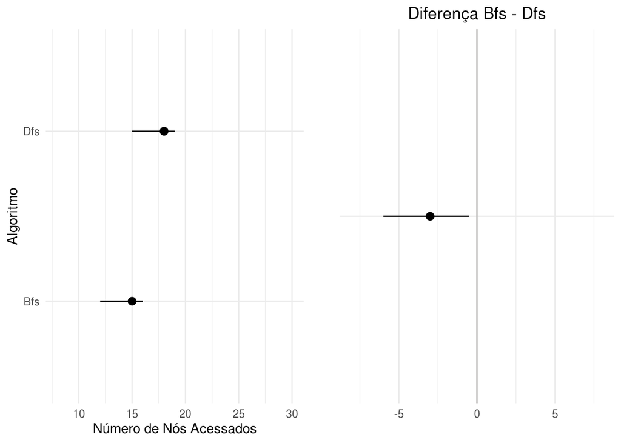

Como foi percebido anteriormente, é possível que o crawler usando o algoritmo Bfs se sobressaia em relação aos demais, foi comparado também os algoritmos Bfs e Dfs. Neste sentido, a Figura k apresenta os intervalos de confianaça para a mediana do número de acessos de nós entre os algoritmos e a diferença entre eles.

De acordo com os intervalos de confiança mostrados na Figura k os intevalos concencetram-se em 12 até 16 na Bfs e 15 até 19 na Dfs. Além disso, baseando-se na diferença *Bfs - Dfs* apresentando o itervalo -6 a -0.5, é constatado a existência de uma possível superioridade no desempenho do crawler focado em relação a mediana do número de nós acessados entre os critérios fiscais em até 6 nós no uso da Bfs em comparação a Dfs. No entanto, é possível que esta diferença seja discreta, sendo até mesmo imperceptível.

## Como é a estabilidade do crawler considerando cada um dos algoritmos e as combinação de portal de transparência?

Para tentar verificar a estabilidade das avaliações no uso dos diferentes algoritmos foi utilizado a variáveis f1-score e a mediana de número de nós acessados a nível de município e combinações de portais.

### F1 Score e Mediana do número de nós acessados por cada Município da Amostra

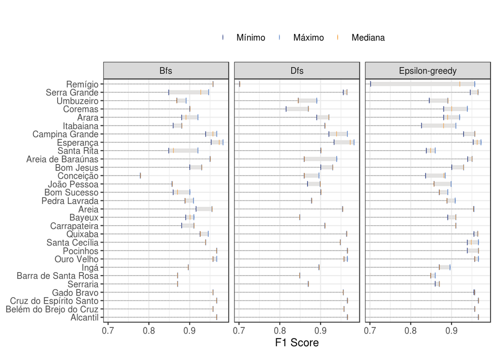

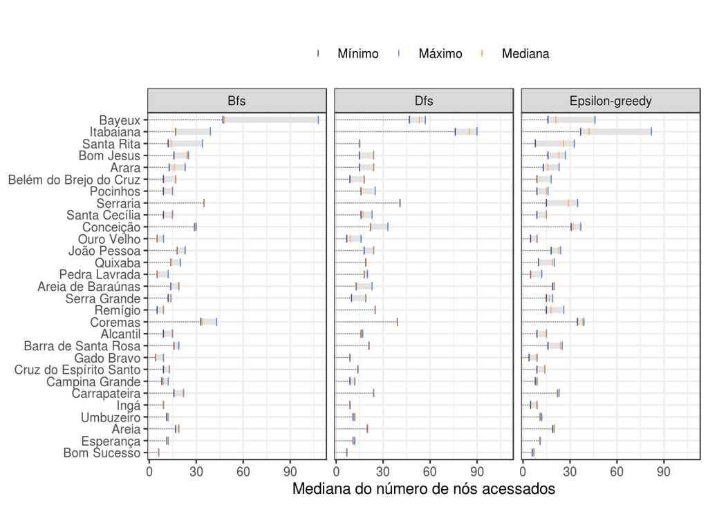

### F1 Score e Mediana do número de nós acessados por cada Combinação de portal da Amostra

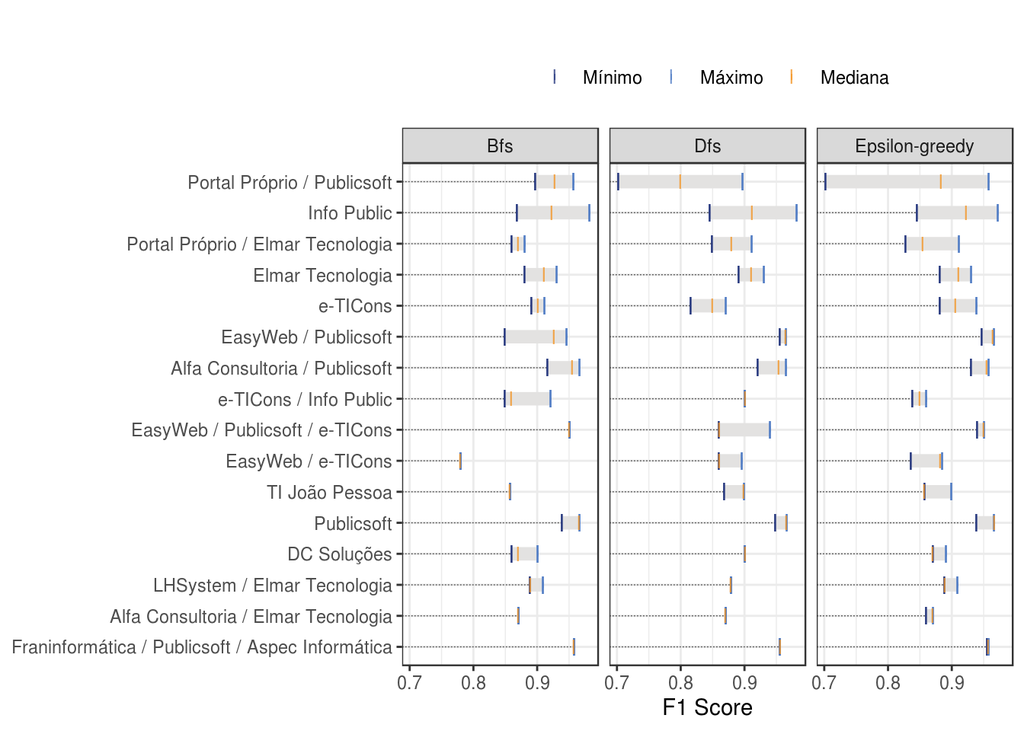

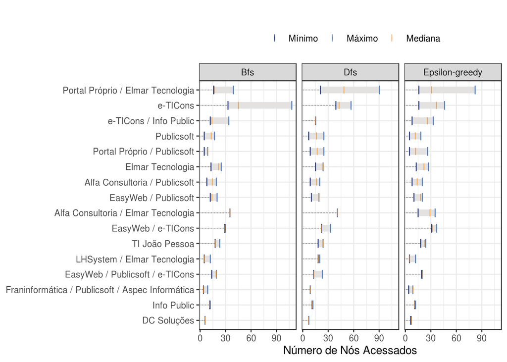

## Número de Avaliações por abordagem

| municipio | bfs | dfs | bandit |
| --- | --- | --- | --- |
| Alcantil | 3 | 3 | 3 |
| Arara | 3 | 3 | 3 |
| Areia | 3 | 3 | 3 |
| Areia de Baraúnas | 3 | 3 | 3 |
| Barra de Santa Rosa | 3 | 3 | 3 |
| Bayeux | 3 | 3 | 3 |
| Belém do Brejo do Cruz | 3 | 3 | 3 |
| Bom Jesus | 3 | 3 | 3 |
| Bom Sucesso | 3 | 3 | 3 |
| Campina Grande | 3 | 3 | 3 |

[output cut: 19 more lines]

## Todas as Avaliações

| municipio | aproach | date | recall | precision | f1_score |
| --- | --- | --- | --- | --- | --- |
| Campina Grande | Bfs | 2019-11-09T23:00:06Z | 1 | 0.934426229508197 | 0.966101694915254 |
| Campina Grande | Dfs | 2019-11-13T03:48:50Z | 1 | 0.933333333333333 | 0.96551724137931 |
| Alcantil | Dfs | 2019-11-22T15:33:46Z | 0.982758620689655 | 0.95 | 0.966101694915254 |
| Alcantil | Dfs | 2019-11-30T03:37:54Z | 0.982758620689655 | 0.95 | 0.966101694915254 |
| Alcantil | Dfs | 2019-12-05T12:49:13Z | 0.982758620689655 | 0.95 | 0.966101694915254 |
| Alcantil | Epsilon-greedy | 2019-12-01T21:04:58Z | 0.982758620689655 | 0.95 | 0.966101694915254 |
| Alcantil | Epsilon-greedy | 2019-12-04T03:28:19Z | 0.982758620689655 | 0.95 | 0.966101694915254 |
| Cruz do Espírito Santo | Dfs | 2019-11-23T02:52:17Z | 0.982758620689655 | 0.95 | 0.966101694915254 |
| Cruz do Espírito Santo | Dfs | 2019-11-26T18:06:55Z | 0.982758620689655 | 0.95 | 0.966101694915254 |
| Cruz do Espírito Santo | Dfs | 2019-12-01T21:04:45Z | 0.982758620689655 | 0.95 | 0.966101694915254 |

[output cut: 251 more lines]